# The Brain & Mind Centre

Day 1

Sydney Informatics Hub

## Introduction to statistics with R

R provides a wide range of functions to implement statistical analysis and modelling on data.

### Descriptive Statistics

All the standard summary statistics are available in R including:

- mean
- sd
- var
- min
- max
- median
- range
- quantile

```r
x <- c(1,3,5,2,9)
mean(x)
```

```
## [1] 4
```

If there are missing values:

```r
x <- c(1,3,5,2,9,NA,7,10)
mean(x)
```

```
## [1] NA
```

```r
mean(x, na.rm=TRUE)
```

```
## [1] 5.285714
```

we can ignore them by setting `na.rm=TRUE`.

```r
x<-c(155, 160, 171, 182, 162, 153, 190, 167, 168, 165, 191)
median(x)
```

```
## [1] 167
```

```r
var(x)     # variance
```

```
## [1] 169.8727
```

```r
sd(x)      # standard deviation
```

```
## [1] 13.03352
```

In R, you can use the function `quantile()` to get median and quartiles, or you can also use the function `summary()`, to get the quantiles as well as the mean:

```r
# mean,median,25th and 75th quartiles,min,max
summary(x)
```

```
##    Min. 1st Qu.  Median    Mean 3rd Qu.    Max.
##   153.0   161.0   167.0   169.5   176.5   191.0
```

There are other functions and packages to obtain summary of statistics of the datasets:

- `sapply()`
- `pastecs()`
- `stat.desc()`
- `describe()` in the Hmisc package
- `describe()` psych package

Read in (again) the gambling dataset:

```r
gambling.data <- read.csv(file = "http://data.justice.qld.gov.au/JSD/OLGR/20170817_OLGR_LGA-EGM-data.csv",
                 header = TRUE,
                 sep = ",",
                 stringsAsFactors = FALSE)

# rename columns
names(gambling.data)[2] <- "Local.Govt.Area"
names(gambling.data)[7] <- "Player.Money.Lost"
names(gambling.data)[1] <- "Month.Year"

gambling.data <- na.omit(gambling.data)

#Add a day of month (1st) to each date string
date.string <- paste0( "1 " , gambling.data$Month.Year )

 #Convert to POSIXlt, a date-time format
strptime( date.string , format = "%d %B %Y" ) -> gambling.data$Date

 # subset to Brisbane only
brisbane.only <- gambling.data[gambling.data$Local.Govt.Area=="BRISBANE",]

# Choose only the brisbane data from 2010
row.indicies <- (brisbane.only$Date>="2010-01-01 AEST" &
                 brisbane.only$Date<="2010-12-31 AEST")
brisbane.2010.data <- brisbane.only[row.indicies,]
```

## Normal Distribution

A common distribution which is used in several statistical tests is a normal distribution. A standard normal distributed dataset is a dataset with variance equal to 1 and mean equal to 0, if you don’t provide these arguments, then these values are assumed.

`pnorm(q)` gives the integrated probability up to `q` standard deviations away from the mean

```r
pnorm(q = 2)
```

```
## [1] 0.9772499
```

```r
pnorm(q = 0)
```

```
## [1] 0.5
```

`qnorm(p)` gives the number of standard deviations away from the mean to get an integrated probability of `p`

```r
qnorm(p = 0.95)
```

```
## [1] 1.644854
```

```r
qnorm(p = 0.025, mean = 2, sd = 0.5)
```

```
## [1] 1.020018
```

`rnorm(n)` gives a vector of `n` random samples from the standard normal distribution (or you can specify a mean and a standard deviation)

```r
rnorm(n = 4, mean = 2, sd = 2)
```

```
## [1]  4.8833341 -0.8651593 -0.3794838  1.4811600
```

Visual ways of checking the distribution of data are histogram, boxplots, and Q-Q plot.

## Histogram

One way to look at the distribution is to plot a histogram of the counts of the data. To obtain a histogram, the scale of the variable is divided into consecutive intervals and the number of observations in each interval is counted.

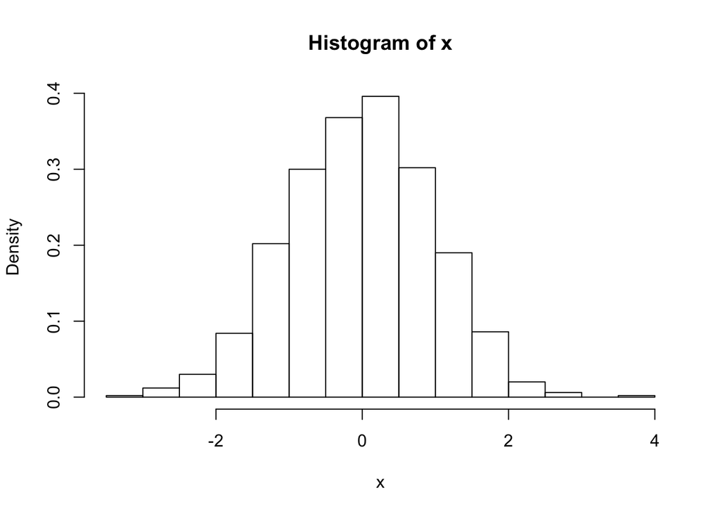

```r
x <- rnorm(1000)
hist(x, freq=F)
```

Histogram with ggplot2:

[figure not shown]

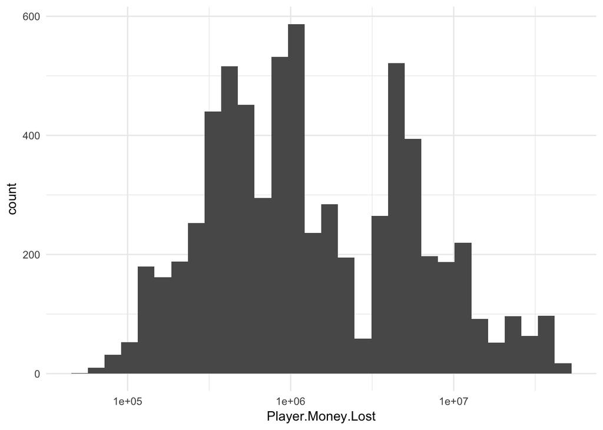

```r
library(ggplot2)
ggplot(data=gambling.data, aes(x=Player.Money.Lost))+
  geom_histogram()+
  scale_x_log10()+
  theme_minimal()
```

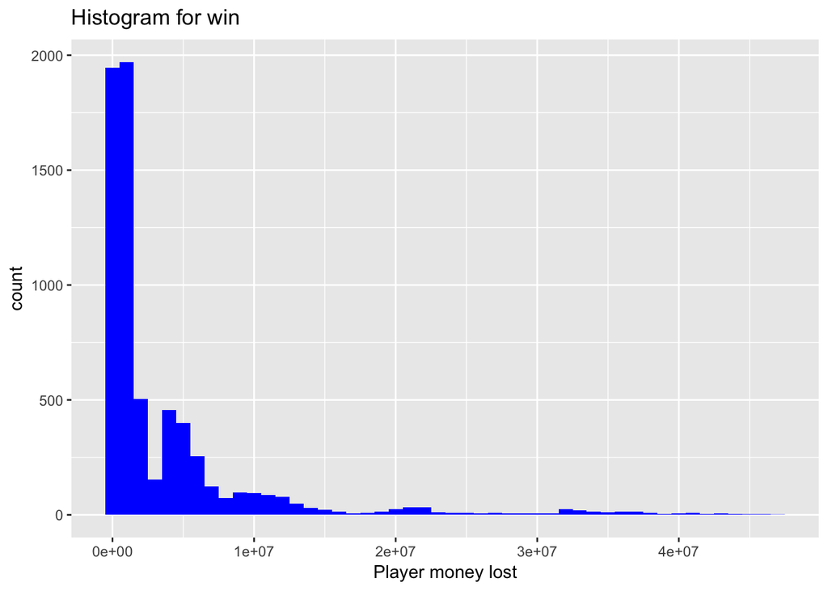

```r
library(ggplot2)
qplot(gambling.data$Player.Money.Lost,
      geom="histogram",
      binwidth = 1000000,
      main = "Histogram for win",
      xlab = "Player money lost",
      fill=I("blue"))
```

### Boxplot

Boxplot also gives an overview of the distribution of the data. It is often used to compare data across different groups. A boxplot is a graphical representation of median and quartiles:

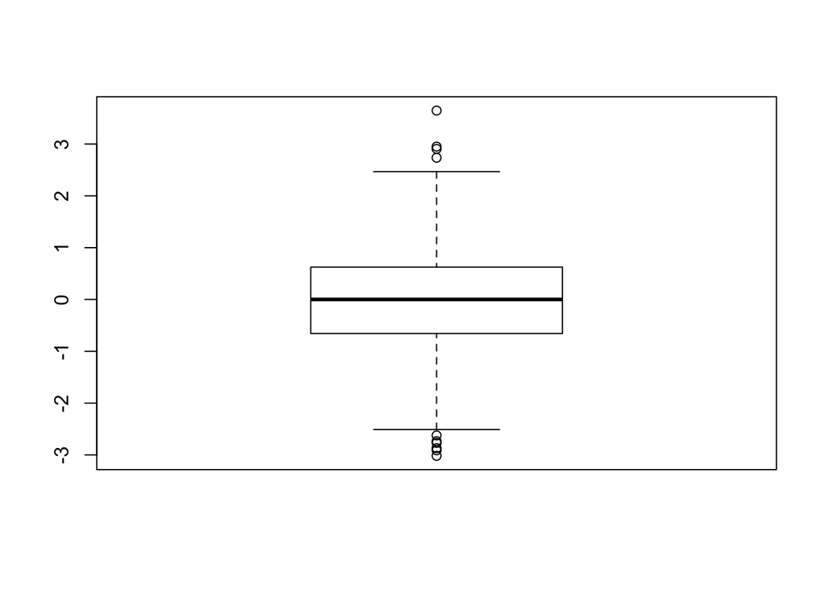

```r
boxplot(x)
```

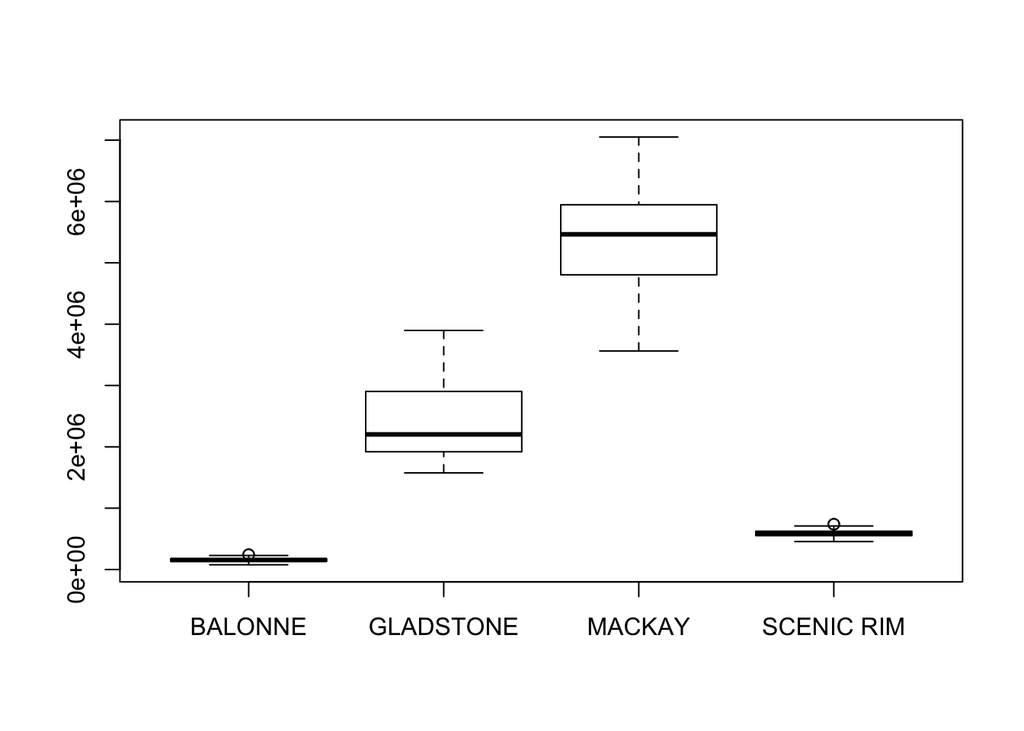

```r
MyData <- gambling.data[ which(gambling.data$Local.Govt.Area %in% c("BALONNE", "GLADSTONE","MACKAY", "SCENIC RIM")) ,]
# Boxplot of Win for different LGA (selected)
boxplot(MyData$Player.Money.Lost ~ MyData$Local.Govt.Area)
```

Plot using ggplot:

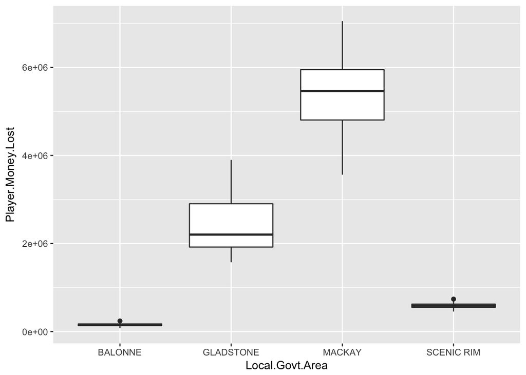

```r
p10 <- ggplot(MyData, aes(x = Local.Govt.Area, y = Player.Money.Lost)) +
        geom_boxplot()
p10
```

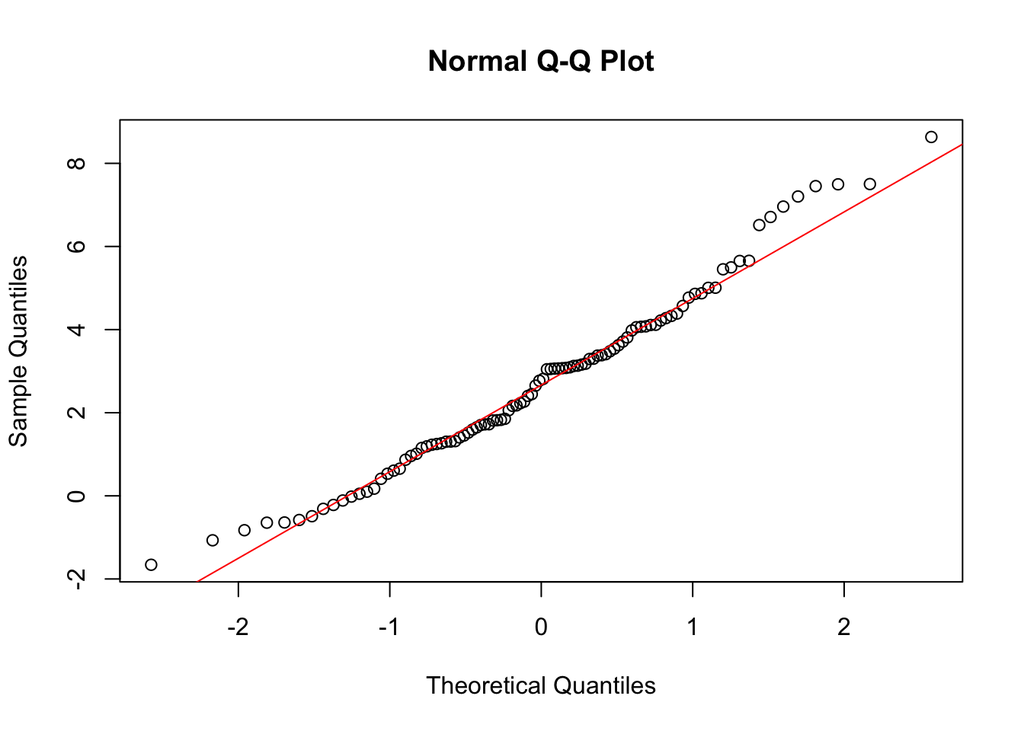

```r
v <- rnorm(100, 3, 2)
qqnorm(v)
qqline(v, col = 2)
```

The Q-Q line is drawn so that it passes through the first and third quantile. All of the points should be on this line when the sample is normal.

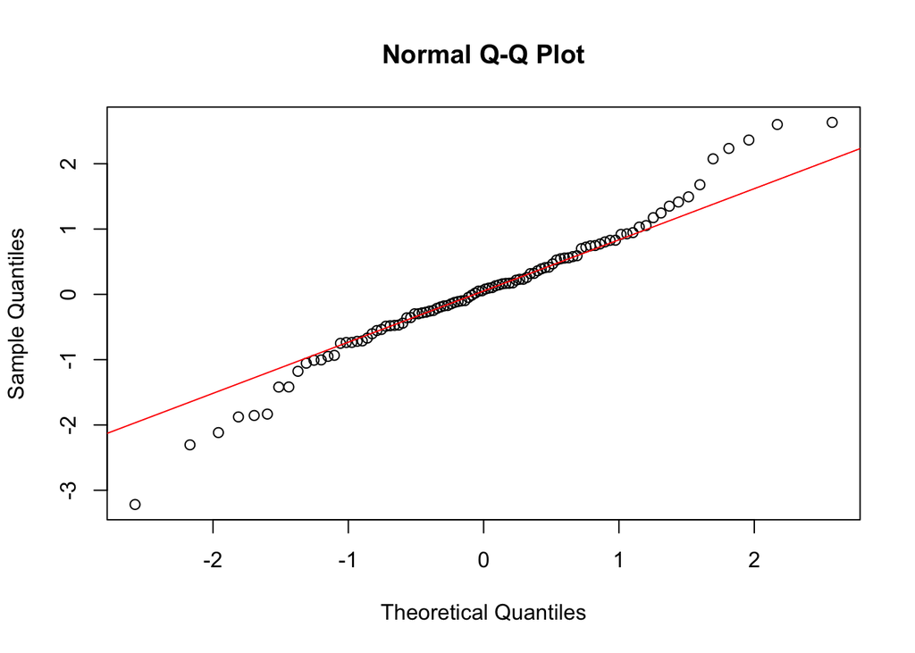

```r
v <- rnorm(100, 0, 1)
qqnorm(v)
qqline(v, col = 2)
```

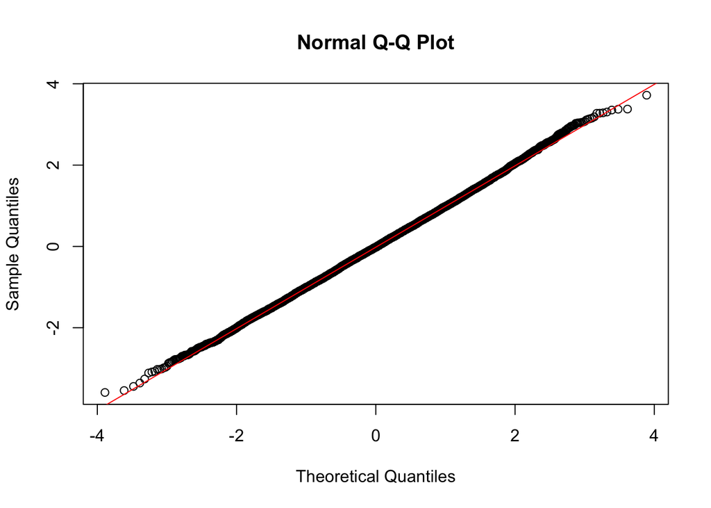

```r
v <- rnorm(10000, 0, 1)
qqnorm(v)
qqline(v, col = 2)
```

Q-Q Plot to Compare Two Samples

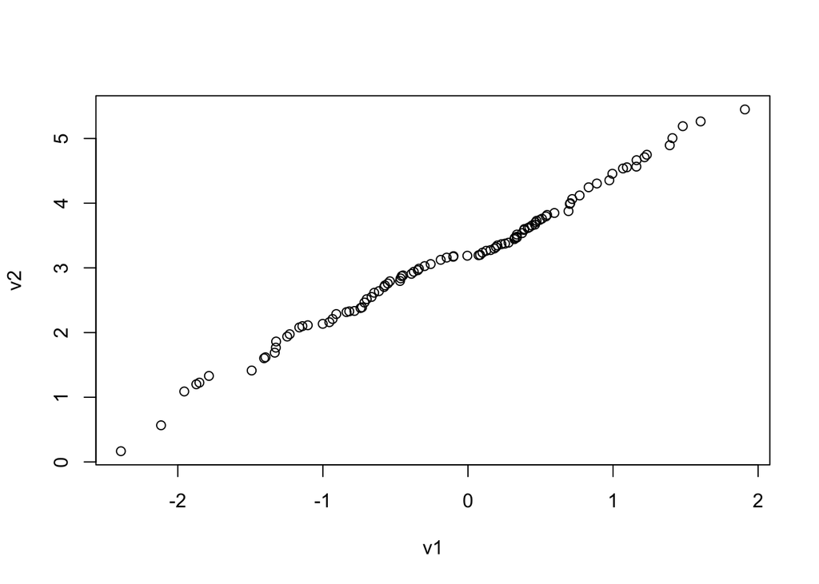

```r
v1 <- rnorm(100, 0, 1)
v2 <- rnorm(150, 3, 1)
qqplot(v1, v2)
```

The most common normalization is the z-transformation, where you subtract the mean and divide by the standard deviation of your variable. The result will have mean=0 and sd=1.

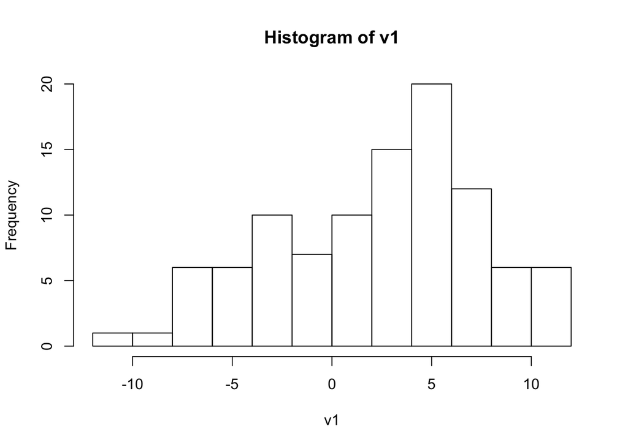

```r
v1 <- rnorm(100, 3, 5)
hist(v1)
```

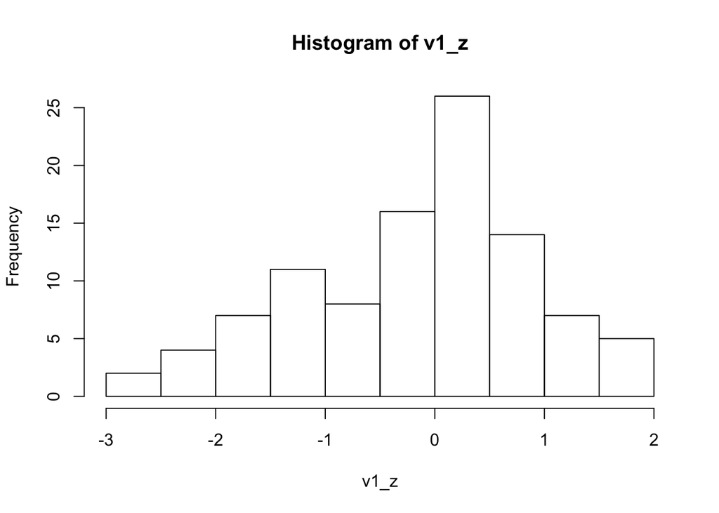

```r
#zVar <- (myVar - mean(myVar)) / sd(myVar)
v1_z <- ((v1 - 3)/5)
hist(v1_z)
```

## Hypothesis testing

A hypothesis testing can determine a cause and effect or associative relationship that is testable, e.g. weight response to deit change. The purpose and design of an experiment is to test the hypothesis. Firstly we set α, arbitrary critical thresholds of probability (P-values). The P-value approach involves determining “likely” or “unlikely” by determining the probabilityby assuming the null hypothesis were true. If the P-value is small (less than or equal to α), then we will reject the null Hypothesis in favor of the alternative hypothesis (“unlikely”); and, if the P-value is greater than α, then the null hypothesis is not rejected. Common α, to determine if the result are statistically significant are P<0.05, P<0.01 and P<0.001.  
Which statistical test you use depends on the type of data you have collected and the question you wish to ask.

### hypothesis tests for population means: One-sample hypothesis test

Let x represents a sample collected from a normal population with unknown mean and standard deviation. We want to test if the population mean is equal to 9, at significance level 5%. The R function t.test() can be used to perform both one and two sample t-tests. The function contains a variety of options and can be called as follows: t.test(x, y = NULL, alternative = c(“two.sided”, “less”, “greater”), mu = 0, paired = FALSE, var.equal = FALSE, conf.level = 0.95).

```r
x= c(6.2, 6.6, 7.1, 7.4, 7.6, 7.9, 8, 8.3, 8.4, 8.5, 8.6,
     8.8, 8.8, 9.1, 9.2, 9.4, 9.4, 9.7, 9.9, 10.2, 10.4, 10.8, 11.3, 11.9)
# Entering the data
t.test(x-9, alternative="two.sided", conf.level=0.95)                             # Performing the t-test
```

```
##
##  One Sample t-test
##
## data:  x - 9
## t = -0.35687, df = 23, p-value = 0.7244
## alternative hypothesis: true mean is not equal to 0
## 95 percent confidence interval:
##  -0.7079827  0.4996494
## sample estimates:
##  mean of x
## -0.1041667
```

### Interpretation of the result

```r
v <- rnorm(10,9, 6)
t.test(v-0, alternative="two.sided", conf.level=0.95)
```

```
##
##  One Sample t-test
##
## data:  v - 0
## t = 10.092, df = 9, p-value = 3.314e-06
## alternative hypothesis: true mean is not equal to 0
## 95 percent confidence interval:
##  11.72623 18.50157
## sample estimates:
## mean of x
##   15.1139
```

### homogeneous variances

Before proceeding with the t-test, it is necessary to evaluate the sample variances of the two groups, using a Fisher’s F-test to verify the homoskedasticity (homogeneity of variances). In R you can do this in this way:

```r
a <- c(175, 168, 168, 190, 156, 181, 182, 175, 174, 179)
b <- c(185, 169, 173, 173, 188, 186, 175, 174, 179, 180)
var.test(a,b)
```

```
##
##  F test to compare two variances
##
## data:  a and b
## F = 2.1028, num df = 9, denom df = 9, p-value = 0.2834
## alternative hypothesis: true ratio of variances is not equal to 1
## 95 percent confidence interval:
##  0.5223017 8.4657950
## sample estimates:
## ratio of variances
##           2.102784
```

We obtained p-value greater than 0.05, then we can assume that the two variances are homogeneous. Indeed we can compare the value of F obtained with the tabulated value of F for alpha = 0.05, degrees of freedom of numerator = 9, and degrees of freedom of denominator = 9, using the function qf(p, df.num, df.den):

```r
qf(0.95, 9, 9)
```

```
## [1] 3.178893
```

Note that the value of F computed is less than the tabulated value of F, which leads us to accept the null hypothesis of homogeneity of variances. NOTE: The F distribution has only one tail, so with a confidence level of 95%, p = 0.95. Conversely, the t-distribution has two tails, and in the R’s function qt(p, df) we insert a value p = 0975 when you’re testing a two-tailed alternative hypothesis.

### Two-sample hypothesis test

```r
t.test(a,b, var.equal=TRUE, paired=FALSE)
```

```
##
##  Two Sample t-test
##
## data:  a and b
## t = -0.94737, df = 18, p-value = 0.356
## alternative hypothesis: true difference in means is not equal to 0
## 95 percent confidence interval:
##  -10.93994   4.13994
## sample estimates:
## mean of x mean of y
##     174.8     178.2
```

### Interpretation of the result

```r
qt(0.975, 18)
```

```
## [1] 2.100922
```

This confirms that we can accept the null hypothesis H0 of equality of the means.

### Confidence interval

If we are interested in finding the confidence interval for the difference of two population means, the R-command “t.test” is also to be used.

```r
x=c(418,421,421,422,425,427,431,434,437,439,446,447,448,453,454,463,465)          # Entering the data into the R-workspace
y=c(429,430,430,431,36,437,440,441,445,446,447)
test2<-t.test(x,y,alternative="two.sided",mu=0,var.equal=F,conf.level=0.95)       # Performing a t-test procedure, containing a confidence interval computation
test2
```

```
##
##  Welch Two Sample t-test
##
## data:  x and y
## t = 1.0123, df = 10.202, p-value = 0.3348
## alternative hypothesis: true difference in means is not equal to 0
## 95 percent confidence interval:
##  -44.46343 118.86984
## sample estimates:
## mean of x mean of y
##  438.2941  401.0909
```

### Chi-Squared Test

Dataset use is survey, the Smoke column records the students smoking habit, while the Exer column records their exercise level. The allowed values in Smoke are “Heavy”, “Regul” (regularly), “Occas” (occasionally) and “Never”. As for Exer, they are “Freq” (frequently), “Some” and “None”. Make a the contingency table of the two variables, the students smoking habit against the exercise level using the table function in R. The result is called the contingency table of the two variables.

```r
library(MASS)       # load the MASS package
tbl = table(survey$Smoke, survey$Exer)
tbl                 # the contingency table
```

```
##
##         Freq None Some
##   Heavy    7    1    3
##   Never   87   18   84
##   Occas   12    3    4
##   Regul    9    1    7
```

Question: test the hypothesis whether the students smoking habit is independent of their exercise level at 0.05 significance level. Solution:We apply the chisq.test function to the contingency table tbl, and found the p-value.

```r
chisq.test(tbl)
```

```
## Warning in chisq.test(tbl): Chi-squared approximation may be incorrect
```

```
##
##  Pearson's Chi-squared test
##
## data:  tbl
## X-squared = 5.4885, df = 6, p-value = 0.4828
```

Answer: As the p-value 0.4828 is greater than the .05 significance level, we do not reject the null hypothesis that the smoking habit is independent of the exercise level of the students.

Enhanced Solution The warning message found in the solution above is due to the small cell values in the contingency table. To avoid such warning, we combine the second and third columns of tbl, and save it in a new table named ctbl. Then we apply the chisq.test function against ctbl instead.

```r
ctbl = cbind(tbl[,"Freq"], tbl[,"None"] + tbl[,"Some"])
ctbl
```

```
##       [,1] [,2]
## Heavy    7    4
## Never   87  102
## Occas   12    7
## Regul    9    8
```

```r
chisq.test(ctbl)
```

```
##
##  Pearson's Chi-squared test
##
## data:  ctbl
## X-squared = 3.2328, df = 3, p-value = 0.3571
```

## Anova

### Multiple (Linear) Regression

```r
 #
#fit <- lm(read ~ write + math + science +socst, data=hs0)
#summary(fit) # show results
```

```r
# Other useful functions
#coefficients(fit) # model coefficients
#confint(fit, level=0.95) # CIs for model parameters
#fitted(fit) # predicted values
#residuals(fit) # residuals
#anova(fit) # anova table
#vcov(fit) # covariance matrix for model parameters
#influence(fit) # regression diagnostics
```

Diagnostic Plots Diagnostic plots provide checks for heteroscedasticity, normality, and influential observerations.

```r
# diagnostic plots
#layout(matrix(c(1,2,3,4),2,2)) # optional 4 graphs/page
#plot(fit)
```

```r
# compare models
#fit1 <- lm(read ~ write + math + science +socst, data=hs0)
#fit2 <- lm(read ~ write + math , data=hs0)
#anova(fit1, fit2)
```

## more information:

### Tarnsformation to chnege a dataset to normally distributed dataset

Some measurements in nature are naturally normally distributed. Other measurements are naturally log-normally distributed.  
Approach can be used here is to transform one or more variables to better follow a normal distribution. For right-skewed data—tail is on the right, positive skew—, common transformations include square root, cube root, and log. For left-skewed data—tail is on the left, negative skew—, common transformations include square root (constant – x), cube root (constant – x), and log (constant – x). Another approach is to use a general power transformation, such as Tukey’s Ladder of Powers or a Box–Cox transformation. These determine a lambda value, which is used as the power coefficient to transform values. X.new = X ^ lambda for Tukey, and X.new = (X ^ lambda – 1) / lambda for Box–Cox. The Box–Cox procedure is included in the MASS package with the function boxcox. It uses a log-likelihood procedure to find the lambda to use to transform the dependent variable for a linear model (such as an ANOVA or linear regression). Useful link: http://rcompanion.org/handbook/I_12.html http://www.statisticssolutions.com/transforming-variables-to-meet-an-assumption/ ### Hypothesis testing https://onlinecourses.science.psu.edu/statprogram/node/138 https://www.r-bloggers.com/hypothesis-testing-on-normally-distributed-data-in-r/